# Marketing Analytics Project: Black Friday

Weicheng Zhang, Zilei Zhang, Maura Oray, Gloria Zheng

**1. Introduction**

Every year in America, there is one day where retail stores make the most money. In fact, stores made over $5 billion online from customers on this day in 2017[^1]. This date is always the day after Thanksgiving, and it’s called “Black Friday.” In our dataset, a particular company wants to gain a better understanding about customer purchasing behavior, because Black Friday is the most profitable day of the year. The company also aims to compare different products to see which ones customers are buying more, and also the demographics of the customers. Having this information could be useful for marketing so that they can target particular customer segments for particular products, and also affect company purchasing decisions for the next year.

In this project, we aim to:  
* Look at the distribution of customer demographics  
* Determine which variables are highly correlated with purchase  
* Identify which products are high-selling

The dataset comes from a competition hosted by Analytics Vidhya.

Group Github url: https://github.com/MauraO/Marketing-Analytics-Project

**2. Data Description**

**a. Describe the conceptual measure types of the different variables**

User_ID (discrete, nominal), Product_ID (discrete, nominal), Gender (discrete, nominal), Age (discrete, ordinal), Occupation (discrete, nominal), City_Category (discrete, nominal), Stay_in_Current_City_Years (continuous, ratio), Marital_Status (discrete, nominal), Product_Category_1 (discrete, nominal), Product_Category_2 (discrete, nominal), Product_Category_3 (discrete, nominal), and Purchase (continuous, ratio).

**b. Mention all the steps you took to clean the data**

**Step 1. Check if the data contains missing values**

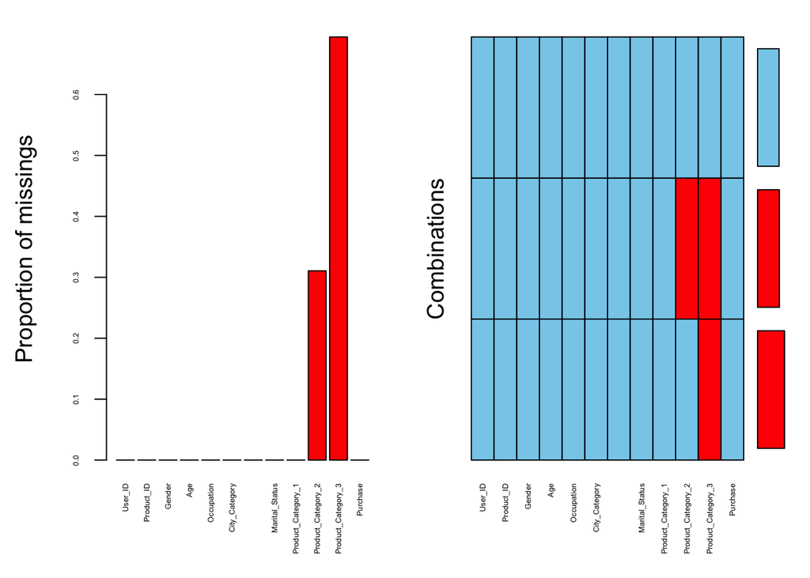

```r
sum(complete.cases(BF))
aggr(BF,cex.axis = .4)
```

In the visualization in the appendix, we wanted to see which variables had the most NA values. We see that the NA values were only concentrated in Product Category 2 and Product Category 3 (red indicates the location of NA values). Because these two variables are sub categories of Product Category 1 and our further analysis does not use them, we deleted them and made a new data set later.

**Step 2. Check the structure of the data**

```r
summary(BF)
str(BF)
```

In this part, we wanted to see the type of variables for later use (group_by). We found that there were no factors, which leads us to the next step.

**Step 3. Type coercion**

```r
BF[1:11] = lapply(BF[1:11], factor)
```

The majority of the variables were either integers or characters. We decided to change the variables into factors (all except purchase) because the majority of them are categorical, and coercing to factors makes for easier and clearer analysis (group_by).

**Step 4. Tidy the data**

```r
#Select demographic data
demo = BF %>%
  select(-starts_with("Product")) %>%
  group_by(User_ID) %>%
  mutate(Purchase = sum(Purchase))
demo = demo[!duplicated(demo$User_ID), ]
```

Because we decided to focus more on customer analysis instead of the product, and that Product Category 2 and Product Category 3 had a lot of missing data, we deleted all of the product category columns to make a clearer customer data set. Moreover, we found that the Customer IDs were repeated many times which is redundant and we needed a purchase sum. Therefore, we used customers’ whole purchase amount to replace the individual product purchase and deleted the redundant customer IDs.

**3. Summary statistics and Data Visualizations** **Customer Demographics**

**Plot 1. Distribution of Purchase**

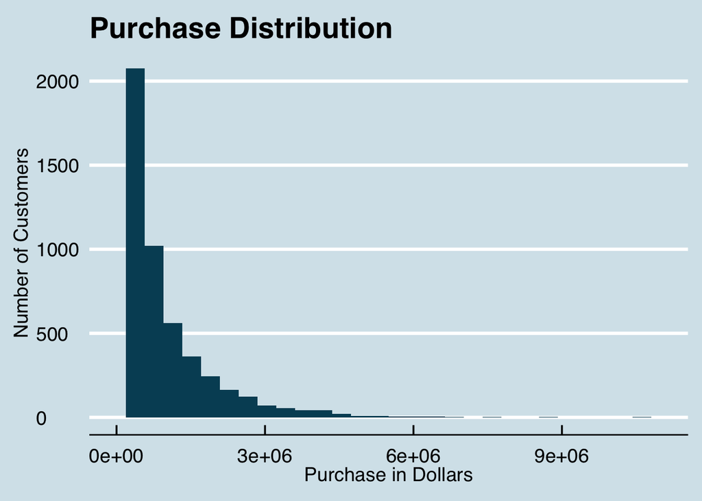

```r
demo %>%
  ggplot(aes(Purchase)) +
  geom_histogram(fill = "#014d64") +
  scale_x_continuous(limits = c(0, 11000000)) +
  theme_economist(base_size=14)+
  scale_fill_economist()+
  labs(x = "Purchase in Dollars", y = "Number of Customers", title = "Purchase Distribution")
```

Here we selected the variable “Purchase.” We decided to use a histogram to view the distribution of customers and purchase because it is the best way to display continuous data. From the graph, it shows a downward slope between number of customers and purchase, which illustrates that a larger number of customers spend less than a smaller number of customers who spend more.  
[1]Glorious Christian, Black Friday Analysis https://www.kaggle.com/gloriousc/black-friday-analysis

**Plot 2. Purchase Distribution by Gender and City**

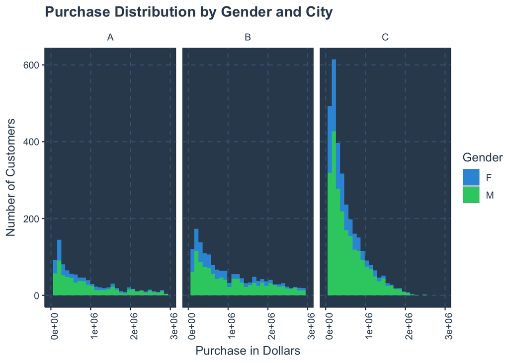

```r
ggthemr('flat dark')
demo %>%
  ggplot(aes(x = Purchase, fill = Gender)) +
  geom_histogram() +
  facet_wrap(~City_Category) +
  scale_x_continuous(limits = c(0, 3000000)) +
  labs(x = "Purchase in Dollars", y = "Number of Customers", title = "Purchase Distribution by Gender and City")+
  theme(axis.text.x = element_text(angle = 90, hjust = 0.5))
```

**Plot 3. Purchase Distribution by Occupation**

[figure not shown]

```r
#Create new data frame grouping by occupation and marital status, and taking the mean purchase of each occupation and status.
ggthemr_reset()
demo %>%
  group_by(Occupation) %>%
  ggplot(aes(x = fct_infreq(Occupation), y = sum(Purchase), fill = Marital_Status)) +
  geom_bar(stat = "identity") +
  theme_minimal() +
  coord_flip() +
  labs(x = "Occupation", y = "Purchase in Dollars", title = "Purchase Distribution by Occupation", fill="Marital Status") +
    scale_fill_discrete(labels=c("Unmarried", "Married"))
```

We were interested in determining which occupations spend more and whether married customers spend more than unmarried customers. Since marital status and occupation are factors (discrete) variables, and purchase is a continuous variable, we used a barplot to show total purchase for each occupation, split by matital status. Without looking at the marital status, this barplot shows the purchase distribution among 21 occupations and can answer questions such as “How much do customers from occupation x spend on Black Friday?” Taking into account marital status, the plot answers whether married or unmarried customers spend more. We improved the plot by flipping the coordinates and reordering the purchase by occupation in ascending order.  
Generally, unmarried customers spend more on Black Friday and this holds true for most occupations. Specifically, occupations 17, 1, 7, 0 and 4 spend the most money, over $2 trillion, out of which occupation 4 purchases the most. Interestingly, for occupation 10, married customers hardly spend money on Black Friday.

**Plot 4. Purchase Distribution by Age**

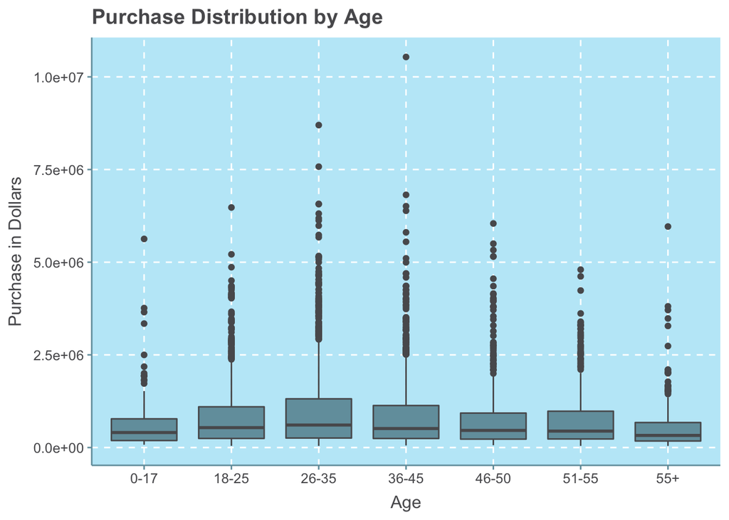

```r
ggthemr('sky')
demo %>%
  ggplot(aes(x = Age, y = Purchase)) +
  geom_boxplot() +
  labs(x = "Age", y = "Purchase in Dollars", title = "Purchase Distribution by Age")
```

**Plot 5. Purchase distribution by stay in city years**

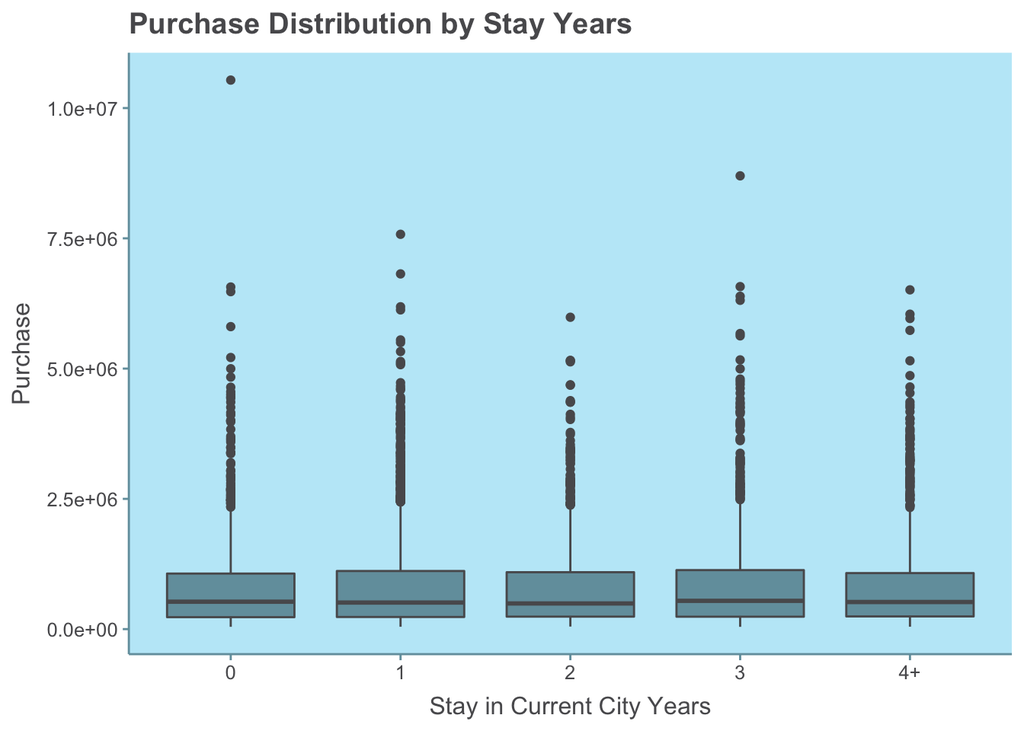

```r
ggthemr('sky', layout = 'minimal')
demo %>%
  ggplot(aes(x = Stay_In_Current_City_Years, y = Purchase)) +
  geom_boxplot()+
  labs(x = "Stay in Current City Years", y = "Purchase", title = "Purchase Distribution by Stay Years")
```